# A0: Warmup

*Purpose*: This assignment will get you up-to-speed on the preliminaries we'll use throughout the course.

*Learning Objectives*: By working through this assignment, you will

- (re-)learn mathematical basics
- identify assumptions and limitations in a model
- translate a problem statement into an optimization problem
- use Python code to implement mathematical statements
- interpret optimization results
- begin thinking about your project

*Readings*:

- (Required) [All Models Are Wrong](https://theconversation.com/all-models-are-wrong-a-computational-modeling-expert-explains-how-engineers-make-them-useful-253309), motivation for *tenchi* diagrams

### Assignment Checklist

1. [?] Make sure you have answered all questions. These are marked with a **qX.Y**
2. [?] Make sure you complete the Project Task at the end of the assignment. These will scaffold your project progress during the semester.
3. [?] Make sure your notebook passes all `assert()` statements. You will not get full credit for the assignment if a single `assert()` fails.
4. [?] Make sure your notebook runs: `Kernel > Restart kernel and run all cells...`
5. [?] Upload your notebook to Canvas.

### Grading Rubric

Every assignment is worth 10 points; it is not possible to receive less than 0 points. For each question (qX.Y) on a given assignment, the following grading rubric will be applied. For every NI that you receive, one point will be subtracted from your assignment total. For reference, to receive an A- in this class, you will need an average of 9 points across your 5 best assignments, meaning you need to have at most one mistake on your final submission for 5 assignments. To achieve this, you should take advantage of both the Draft and Final submission deadlines.

| Category | Needs Improvement (NI) | Satisfactory (S) |
| --- | --- | --- |
| Effort | qX.Y left unattempted | qX.Y attempted |
| Assertions | Code does not pass an `assert()` | All `assert()`s pass, or no assertions |
| Observations | Any point under *observe* left unattempted | All *observe*s attempted and correct, |
|  | Provided an incorrect observation | or no *observe*s for that q |

## A Note on Jupyter

This document is a Jupyter notebook, a combination of executable code and human-readable text. The notebook is organized into *cells*, each of which can be either of type `Markdown` or `Code`.

All of your work in this class is required to be submitted as a Jupyter notebook.

Some key features to note:

- You can select a cell by clicking on it once.
  - The thin **blue** rectangle to the left highlights the cell that you have **selected**. When you press `Ctrl + Enter` you will *execute* your selected cell.
- `Markdown` cells contain human-readable text written in [Markdown](https://www.markdownguide.org/basic-syntax/).
- By default, `Markdown` cells cannot be edited. You can select (click once) then edit (click twice) to reveal the underlying Markdown code, which you can then edit.
  - When in doubt, click a `Markdown` cell three times to edit it.
  - When you're done editing a `Markdown` cell, you can press `Ctrl + Enter` to render the cell, which makes it easier to read.
- `Code` cells contain executable code; you can write and run code from the notebook.
  - A single notebook has a single *instance* of Python running; this means all variables are global variables, available across the entire notebook. So you can load packages in one cell, set up data in a second cell, and analyze the data in a third cell.
  - Pressing `Ctrl + Enter` *executes* a `Code` cell, running the Python code inside.
- You can create new cells by clicking `Insert > Insert Cell Above` (keyboard shortcut `A`) or `Insert > Insert Cell Below` (keyboard shortcut `B`).
  - You can change the type of a cell by clicking `Cell > Cell Type > ...`.

For a longer tutorial on Jupyter, see e.g. [this page](https://www.dataquest.io/blog/jupyter-notebook-tutorial/).

## S1: Python Basics

To do useful work with Python, we will use a number of standard *modules*.

It is standard to import modules `as` a particular prefix, so as to control your *namespace* and keep track of which function comes from which module. For instance, if we wanted to use `log` from `numpy` and we called `import numpy as np`, we could access log by calling `np.log(x)`.

### **q1.1** Loading modules

Fix the code below to call `sin` from the appropriate module. Note that the comments below describe which module provides what kind of functions.

```python
###
# TASK: Fix the code below by calling from the appropriate library
###

# NO NEED TO EDIT
import grama as gr              # Modeling module
import numpy as np              # Math / Linear algebra functions
import pandas as pd             # DataFrame module
import scipy as sp              # Optimization functions
DF = gr.Intention()             # DataFrame pronoun

# TODO: Fix the code below by calling from the apropriate module
x = np.sin(np.pi)


# NO NEED TO EDIT; this checks your answer
assert(abs(x) < 1e-6)
print("Success!")
```

```
Success!
```

### Numpy

Numpy is a core library that provides an *array* data structure. These arrays are useful for representing *vectors* in our computations.

Some *quick facts* about accessing numpy arrays:

- Python is a *zero-index* language, meaning you use `0` to access the first element, `1` for the second, etc.
- Python provides the special syntax `[-1]` to access the *last* entry in an array.
- Numpy arrays can be *multi-dimensional*; a one-dimensional array is a vector, while a two-dimensional array is a matrix.
  - For a Numpy matrix `A`, we access entires with a *multi-index* `A[i, j]`
  - The first entry `i` accesses the row number
  - The second entry `j` accesses the column number
  - The special syntax `[:]` returns all the entries along an axis; for instance `A[0, :]` returns the first *row* of the matrix `A`
- Numpy arrays enable numerous vector operations:
  - Addition `v1 + v2`
  - Subtraction `v1 - v2`
  - Inner product `np.dot(v1, v2)`
  - Length `np.linalg.norm(v)`

*Note*: We'll use the terms *array* and *vector* somewhat interchangeably in this course. Note that technically we use arrays to *represent* vectors.

### **q1.2** Arrays

Complete the following exercises using numpy arrays.

```python
###
# TASK: Complete the array operations below
###

# NO NEED TO EDIT
v1 = np.array([1, 2, 3])

# TASK: Extract the first and last elements of v1
x_first = v1[0]
x_last = v1[-1]



# TASK: Subtract the vector [1, 1, 2] from v1
v_diff = v1 - [1, 1, 2]


# TASK: Extract the first *column* of the matrix A below
A = np.array([
    [1, 2, 3],
    [4, 5, 6],
    [7, 8, 9],
])
v_col0 = A[:, 0]


# NO NEED TO EDIT; this checks your answers
assert(abs(x_first - 1) < 1e-6)
assert(abs(x_last - 3) < 1e-6)

assert(abs(v_diff[0] - 0) < 1e-6)
assert(abs(v_diff[1] - 1) < 1e-6)
assert(abs(v_diff[2] - 1) < 1e-6)

assert(abs(v_col0[0] - 1) < 1e-6)
assert(abs(v_col0[1] - 4) < 1e-6)
assert(abs(v_col0[2] - 7) < 1e-6)

print("Success!")
```

```
Success!
```

### Functions

In Python, functions are defined with the `def` keyword; for instance:

```
def foo(x):
    """Operate on x"""
    y = x + 1
    z = x**2

    return y + z
```

Remember that you have to specify the result of a function with the `return` keyword.

Most Python functions we'll use---including the optimization routines---will expect functions that take an array as input. To make use of these tools, you'll need to be able to write functions that take an array as an input.

### **q1.3** Writing functions

Complete the function-writing tasks below.

*Hint*: We can use an "unpacking syntax" to make working with vector entires easier; for instance we can use the syntax `x, y = X` to assign the first entry of `X` to `x`, and its second entry to `y`.

```python
###
# TASK: Implement the functions below
###

# TASK: Implement the function f(X = [x, y]) = x - y
def fun_scalar(X:list) -> float:
    """
    Function performs function f(X = [x, y]) = x-y, returning the difference between x and y values.
    Args:
        X (1-row array): Represents a 1-row array with values on which to perform the function.
    Returns:
        f_x (float): Represents function output at input values.
    """
    x = X[0]
    y = X[1]

    f_x = x-y

    return f_x


v_q = np.array([1, 1])

def fun_vector(X:list) -> np.array:
    # HINT: This one is easier if you *don't* unpack the values!
    """
    Returns the difference between the input vector and the numpy array v_q.
    Args:
        X (list): Input vector containing x and y values.
    Returns:
        v_res (numpy array): Difference between X and v_q vectors.
    """
    v_res = X - v_q
    return v_res


# NO NEED TO EDIT; this checks your answer
res1 = fun_scalar([1, 0])
res2 = fun_scalar([0, 1])
assert(abs(res1 - 1) < 1e-6)
assert(abs(res2 + 1) < 1e-6)

v_res = fun_vector([3, 2])
assert(abs(v_res[0] - 2) < 1e-6)
assert(abs(v_res[1] - 1) < 1e-6)

print("Success!")
```

```
Success!
```

## Consulting Documentation

No real programmer *memorizes* all the details of every function they work with. Instead, competent programmers *frequently consult documentation*. In order to be successful in this course, you will have to consult the documentation for a number of new functions. Jupyter actually makes this very easy to do!

First, you can always create a new code chunk, type `help(fun)`, and execute to show the documentation for a function `fun`. You can also click on a function already written in a code chunk to place your cursor on that function, and press `Shift + Tab` to open the documentation in a *hover menu*. You may need to press the `+` button in the hover menu to expand the documentation so you can read it. This will allow you to quickly reference documentation while writing code.

### q1.1 Consult the documentation

Use the `Shift + Tab` functionality to consult the documentation for `gr.ft_nls()`. Answer the questions below.

*Hint*: Due to quirks of Jupyter, you may have to put your cursor **inside the argument** for `gr.ft_nls(...)` for `Shift + Tab` to work; that is, between the parentheses that follow `gr.ft_nls`.

```python
###
# TASK: Use Shift + Tab to look up the documentation for gr.ft_nls()
###

# NOTE: No need to edit; run if interested, but primarily use
#       Shift + Tab to look up the documentation for gr.ft_nls()
from grama.models import make_trajectory_linear
from grama.data import df_trajectory_full

md_trajectory = make_trajectory_linear()
md_fitted = (
    df_trajectory_full
    >> gr.ft_nls(md=md_trajectory)
)

md_fitted.printpretty()
```

```
... fit_nls setting out = ['x', 'y']
... eval_nls setting var_fix = []
... eval_nls setting var_feat = {'t'}
Estimated runtime: 0.0000 sec
          u0         v0       tau  u0_0  v0_0  tau_0  success  \
0  20.983275  29.439448  2.109776   0.1   0.1   0.05     True

                                            message  n_iter       mse
0  CONVERGENCE: NORM_OF_PROJECTED_GRADIENT_<=_PGTOL      46  1.967336
model: Trajectory Model (Fitted)

  inputs:
    var_det:
      t: (unbounded)

    var_rand:

    copula:
      None

  functions:
      Fix variable levels: ['t'] -> ['u0', 'v0', 'tau']
      Trajectory Model: ['v0', 't', 'u0', 'tau'] -> ['x', 'y']
```

```python
help(gr.ft_nls)
```

```
Help on NewPipe in module grama.tools object:

fit_nls = class NewPipe(pipe)
 |  fit_nls(function)
 |  Fit a model with Nonlinear Least Squares (NLS)
 |  Estimate best-fit variable levels with nonlinear least squares (NLS), and return an executable model with those frozen best-fit levels. Optionally, fit a distribution on the parameters to quantify parametric uncertainty.
 |  Note that it is **highly likely** you will need to adjust either the bounds of your model or the initial guess of the optimizer (via `df_init`). Use these to guide the optimizer towards *reasonable* input values, otherwise you are likely to get nonsensical results.
 |  Note: This is a *synonym* for eval_nls(); see the documentation for eval_nls() for keyword argument options available beyond those listed here.
 |  Args:
 |      df_data (DataFrame): Data for estimating best-fit variable levels.
 |          Variables not found in df_data optimized for fitting.
 |      md (gr.Model): Model to analyze. All model variables
 |          selected for fitting must be bounded or random. Deterministic
 |          variables may have semi-infinite bounds.
 |      var_fix (list or None): Variables to fix to nominal levels. Note that
 |          variables with domain width zero will automatically be fixed.
 |      df_init (DataFrame): Initial guesses for parameters; overrides n_restart
 |      n_restart (int): Number of restarts to try; the first try is at the nominal conditions of the model. Returned model will use the least-error parameter set among restarts tested.
 |      n_maxiter (int): Optimizer maximum iterations
 |      verbose (bool): Print best-fit parameters to console?
 |      uq_method (str OR None): If string, select method to quantify parameter uncertainties. If None, provide best-fit values only. Methods:
 |          uq_method = "linpool": assume normal errors; linearly approximate parameter effects; equally pool variance matrices for each output
 |  Returns:
 |      gr.Model: Model for evaluation with best-fit variables frozen to
 |          optimized levels.
 |  Examples::
 |      import grama as gr
 |      from grama.data import df_trajectory_windowed
 |      from grama.models import make_trajectory_linear
 |      DF = gr.Intention()
 |      md_trajectory = make_trajectory_linear()
 |      ## Fit
 |      md_fitted = (
 |          df_trajectory_windowed
 |          >> gr.ft_nls(md=md_trajectory)
 |      )
 |      ## Fit, stabilize with initial guess
 |      md_fitted = (
 |          df_trajectory_windowed
 |          >> gr.ft_nls(
```

[output cut: 17 more lines]

```
 |  Methods inherited from pipe:
 |  __call__(self, *args, **kwargs)
 |      Call self as a function.
 |  __init__(self, function)
 |      Initialize self.  See help(type(self)) for accurate signature.
 |  __repr__(self)
 |      Return repr(self).
 |  __rrshift__(self, other)
 |  __rshift__(self, other)
 |  ----------------------------------------------------------------------
 |  Data descriptors inherited from pipe:
 |  __dict__
 |      dictionary for instance variables (if defined)
 |  __weakref__
 |      list of weak references to the object (if defined)
```

[output not shown]

*Observe*:

- What does "NLS" stand for, in the context of `ft_nls()`?
  - NLS stands for 'Nonlinear Least Squares', which is a method to fit data to a model with nonlinear parameters.
- How can you change the number of restarts to try with `ft_nls()`? What argument would you set?
  - You would set the 'n_restart' argument.

## Contour Plots

A [contour plot](https://en.wikipedia.org/wiki/Contour_line) is a 2D visualization of the *contour lines* (aka the [level sets](https://en.wikipedia.org/wiki/Level_set)) of a function of two variables $f(x, y)$. Every curve on a contour plot corresponds to a set of points in $x, y$ that correspond to the *same* output value, that is the set

$$c\text{-contour} \equiv \{x, y\,|\,f(x, y) = c\}.$$

To make sense of optimization, we'll often rely on contour plots. To that end, let's practice interpreting a contour plot.

### **q1.5** Interpreting contour plots

The following contour plot labels each contour line with its corresponding function value $f(x, y)$. Inspect the following contour plot and answer the questions below.

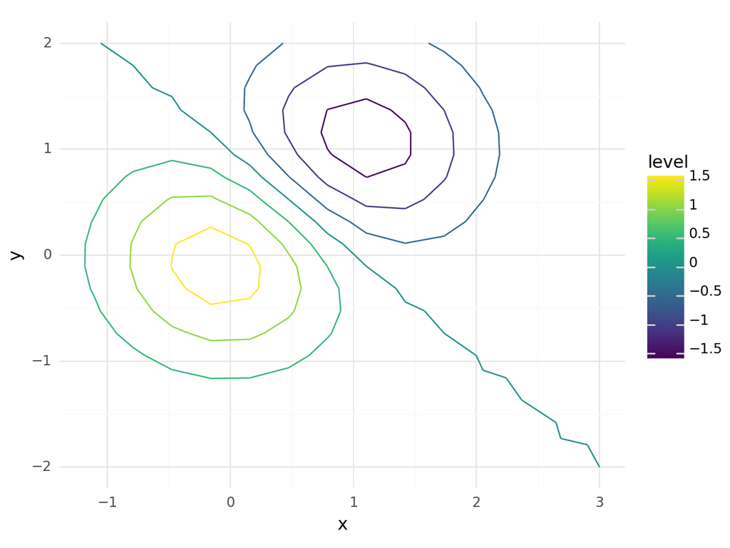

```
<Figure Size: (640 x 480)>
```

```python
# NOTE: No need to edit; run, inspect, and answer the questions below
(
    # Set up model whose contours we'll study
    gr.Model("Example Model")
    >> gr.cp_vec_function(
        fun=lambda df: gr.df_make(
            z=(
                np.exp(-df.x**2 - df.y**2)
              - np.exp(-(df.x - 1)**2 - (df.y - 1)**2)
            ) * 2
        ),
        var=["x", "y"],
        out=["z"],
    )
    >> gr.cp_bounds(
        x=(-3, +3),
        y=(-2, +2),
    )
    # Find the contours
    >> gr.ev_contour(
        var=["x", "y"],
        out=["z"],
        levels=dict(
            z=(-1.5, -1.0, -0.5, +0, +0.5, +1.0, +1.5)
        )
    )
    # Visualize
    >> gr.ggplot(gr.aes("x", "y", color="level"))
    + gr.geom_segment(gr.aes(xend="x_end", yend="y_end"))
    + gr.theme_minimal()
)
```

*Observe*:

- Does the point $x=0, y=0$ correspond to a *minimum* or *maximum* of the function? How do you know?
  - This point is a maximum of the function. The level key represents the 'z' value of the x/y coordinate, and the yellow circle around point (0,0) shows that the level is 1.5, which is the max level.
- Does the point $x=1, y=1$ correspond to a *minimum* or *maximum* of the function? How do you know?
  - This point is a minimum of the function. Same reason as point (0,0); (1,1) has a z level of -1.5, which is the min level.

## S2: Modeling: Arecibo Observatory

Optimization is a branch of mathematics, so to use optimization in engineering, we first need a model. Modeling is a complex activity that goes far beyond just math---but that's why you took ModSim as a first year student! We're going to return to some ideas from ModSim by building a model for a specific engineering system. Let's look at the Arecibo Observatory (Fig. 1), a steerable radio telescope that used to be active in Puerto Rico (a U.S. territory). You can see the steering in action in the 1995 James Bond film [Goldeneye](https://www.youtube.com/watch?v=vovVkvQhYEE).

[figure not shown]

**Figure 1.** [Arecibo Observatory](https://en.wikipedia.org/wiki/Arecibo_Observatory) in Puerto Rico.

As the [required reading](https://theconversation.com/all-models-are-wrong-a-computational-modeling-expert-explains-how-engineers-make-them-useful-253309) mentioned, we can only judge models in response to a chosen use. So let's first specify how we'll use our model:

> Q. How does changing the stiffness in the cables affect the position of the suspended mass?

For this question, we'll highly simplify the actual system to arrive at a very basic model. Figure 2 compares the system we're studying (Arecibo Observatory, in the Natural World) with our simplified model. We're going to neglect the vertical direction and only study lateral movement. Furthermore, we're going to model the cables as linear springs whose equilibrium length is zero. This is an extremely crude model, but it will be very simple to analyze mathematically.

[figure not shown]

**Figure 2.** Tenchi diagram of a highly simplified model for the Arecibo Observatory structure.

The model described above is built on a large number of assumptions which I haven't explicitly stated. Each assumption leads to one (or more) limitations. When building a model, we should do our best to identify these assumptions and limitations.

For example, here's one assumption with two limitations:

- Assumption: No movement of the suspended mass up or down (2d analysis only)
  - Limitation 1: Cannot study how cable stiffness affects vertical position of suspended mass
  - Limitation 2: Cannot represent cable vertical deflection (sag) accurately

You'll practice identifying assumptions and limitations in the next task.

### **q2.1** Identify assumptions and limitations **UPDATED**

Study the diagram above and document the assumptions and limitations of the simplified model. Also, answer the question below.

- Assumption 1: No rotation of the mass (2d analysis only)
  - Limitation: Cannot study how cable stiffness affects rotation of the mass.
- Assumption 2: All cables are identical in material, length, strength, and construction.
  - Limitation: Cannot study how variances in stiffness or cable properties impact position of the mass.
- Assumption 3: The anchors are all fixed, equal, and on the same plane.
  - Limitation: Cannot study how variances in anchor quality, construction, or quality impacts the position of the mass.
- Given these assumptions and limitations, can we use the model to study how cable *length* affects the suspended mass location?
  - You can't study length with this model because we don't have a length parameter. You can only try different stiffness values for the cables.

## S3: Analysis

To continue our warm-up, we're going to analyze the spring model using optimization. We'll do this in multiple steps.

### Case Study: Minimum-energy spring configuration

We'll use the following problem as a warm-up for some fundamentals:

> Let $v_1, v_2, v_3\in\mathbb{R}^2$ be *anchor points* in 2d space, each of which is connected to a single test point $x\in\mathbb{R}^2$ by a spring with spring constant $K_i\in\mathbb{R}_{>0}$ and zero equilibrium length. What is the point $x^*$ that minimizes the energy of the system?

The principle of least-energy implies that this minimum-energy point $x^*$ will be the location where the test point will settle. Our first step will be to translate this problem statement into an optimization problem.

The following code visualizes the problem schematically for a specific choice of anchor points.

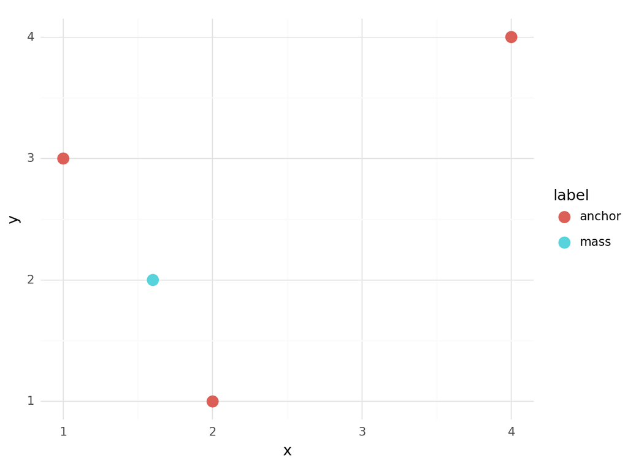

```
<Figure Size: (640 x 480)>
```

```python
# NO NEED TO EDIT; schematic diagram
df_setup = gr.df_make(
    label=["mass", "anchor", "anchor", "anchor"],
    x=[1.6, 1, 2, 4],
    y=[2.0, 3, 1, 4],
)

# Visualize
(
    df_setup
    >> gr.ggplot(gr.aes("x", "y"))
    + gr.geom_point(gr.aes(color="label"), size=4)
    + gr.theme_minimal()
)
```

The first step in solving a problem with optimization is to *translate* it into an optimization problem! the *standard form* for an optimization problem is the following:

$$\min f(\vec{x})$$ $$\text{wrt} \,\vec{x}$$ $$\text{s.t.} \,g(\vec{x}) \leq 0$$

Each of these pieces is important:

- $\min f(\vec{x})$ is the *objective*; in this case minimize the function $f(\vec{x})$.
- $\text{wrt} \,\vec{x}$ stands for *with respect to* $\vec{x}$; it is important to *specify* which variables are *active* during our optimization.
  - *Note*: The "wrt" line defines, by omission, which inputs are *constants* during optimization.
- $\text{s.t.} \,g(\vec{x}) \leq 0$ denotes a *constraint*; "s.t." is short for *subject to*. Not all optimization problems have constraints.

*Aside*: An optimization problem with constraints *but no objective* is called a *feasibility problem*.

### **q3.1** Translate the problem

Translate the minimum-energy spring problem into standard form. **Don't forget to specify the "wrt" variables!**

**Task**:

(Write your translated optimization problem here; you don't have to use LaTeX if you don't want to.) $$\text{c}(\vec{x}) = E_1(\vec{x}) + E_2(\vec{x}) + E_3(\vec{x}), \text{where } \vec{x} = [x, y]$$ $$\text{c}(\vec{x}) = \frac{1}{2}(K_1\|\vec{x} - \vec{v}_1\|_2^2 + K_2\|\vec{x} - \vec{v}_2\|_2^2 + K_3\|\vec{x} - \vec{v}_3\|_2^2)$$

$$\min c(\vec{x})$$ $$\text{wrt} \,{\vec{x}}$$ $$\text{s.t. none}$$

Once you've derived your objective function $c(x)$, implement it below to check your work.

*Hint 1*: Recall that the energy energy of a spring is given by $E_i = \frac{1}{2} K_i \Delta e_i^2$ where $K_i$ is the spring constant and $\Delta e_i$ is the extension of the spring.

*Hint 2*: Since the springs have zero equilibrium length, their extention is given by the distance between points, that is $\Delta e_i = \|\vec{x} - \vec{v}_i\|_2$, where $\|\vec{x} - \vec{v}\|_2 = \sqrt{(x_1 - v_1)^2 + (x_2 - v_2)^2}$ is the ordinary (Euclidean) distance.

*Hint 3*: The numpy function `np.linalg.norm(d)` implements the math operator $\|\vec{d}\|_2$. You're better off using this **vector operator** rather than using the individual entires of $\vec{x}$.

*Hint 4*: The exponential operator in Python is **not** `^`. Rather it is a double-star `x**2`.

```python
###
# TASK: Implement your objective function below
# NOTE: Your function should have the signature objective(X)
###

# NO NEED TO EDIT; use these constants in your function
# Spring constants
k1 = 1; k2 = 2; k3 = 3
# Anchor points
V = np.array([
    [1, 3],
    [2, 1],
    [4, 4],
])

# TASK: Implement the objective (energy expression)
def objective(X):
    energy_at_point = 0.5*(
        k1 * (np.linalg.norm(X - V[0]))**2 +
        k2 * (np.linalg.norm(X - V[1]))**2 +
        k3 * (np.linalg.norm(X - V[2]))**2
    )
    # Hint: This one is easier if you *do not*
    # unpack X (use np.linalg.norm)
    return energy_at_point



# NO NEED TO EDIT; this checks your answer
res_obj = objective([0, 0])
assert(abs(res_obj - 58) < 1e-6)
print("Success!")
```

```
Success!
```

It is a *necessary* condition for the minimum value of a function to occur at a point where the *gradient* of the function equals zero. We'll use the approach of setting the gradient of our objective to zero to solve this problem.

### **q3.2** Derive the gradient

Derive an expression for the gradient of the energy $\nabla E(x)$.

Once you've derived the gradient, implement it as a function below to check your work.

*Hint*: Note that $\|\vec{x} - \vec{v}\|_2^2 = (\vec{x} - \vec{v})^{\top} (\vec{x} - \vec{v})$ (the inner product of two vectors), so $\nabla_{\vec{x}} \left((\vec{x} - \vec{v})^{\top} (\vec{x} - \vec{v})\right) = 2 (\vec{x} - \vec{v})$ (product rule applied to vectors). You can *greatly* simply your work if you use these vector expressions.

```python
###
# TASK: Implement your gradient function below
# NOTE: Your function should have the signature gradient(X)
###

# NO NEED TO EDIT; use these constants in your function
# Spring constants
k1 = 1; k2 = 2; k3 = 3

# Anchor points
V = np.array([
    [1, 3],
    [2, 1],
    [4, 4],
])

# TODO: Implement your gradient function
def gradient(X):
    """
    Finds gradients of energy of each cable.
    Args:
        X (array):
    """
    delta_E1 = k1 * (X - V[0])
    delta_E2 = k2 * (X - V[1])
    delta_E3 = k3 * (X - V[2])
    v_res = delta_E1 + delta_E2 + delta_E3
    return v_res



# NO NEED TO EDIT; this checks your answer
res_grad = gradient([0, 0])
assert(abs(res_grad[0] + 17) < 1e-6)
assert(abs(res_grad[1] + 17) < 1e-6)

print("Success!")
```

```
Success!
```

As noted above it is a *necessary* condition for the gradient of a function to be zero in order for a point to be the minimum value (in the unconstrained case). A point with $\nabla f(\vec{x}^*) = 0$ is called a *stationary point* $\vec{x}^*$, and under certain conditions a stationary point is also an optimal point. It happens that the minimum-energy spring problem satisfies such conditions, so we can find the minimum energy point by finding the stationary point.

### **q3.3** Find the stationary point

Solve for $\vec{x}^*$ via $\nabla E(\vec{x}^*) = 0$.

Once you've derived the stationary point $\vec{x}^*$ in terms of an analytic expression, implement your solution below to check your work.

```
q2.3 Diagnostics
x_star = [2.83333333 2.83333333]
gradient = [8.8817842e-16 8.8817842e-16]
```

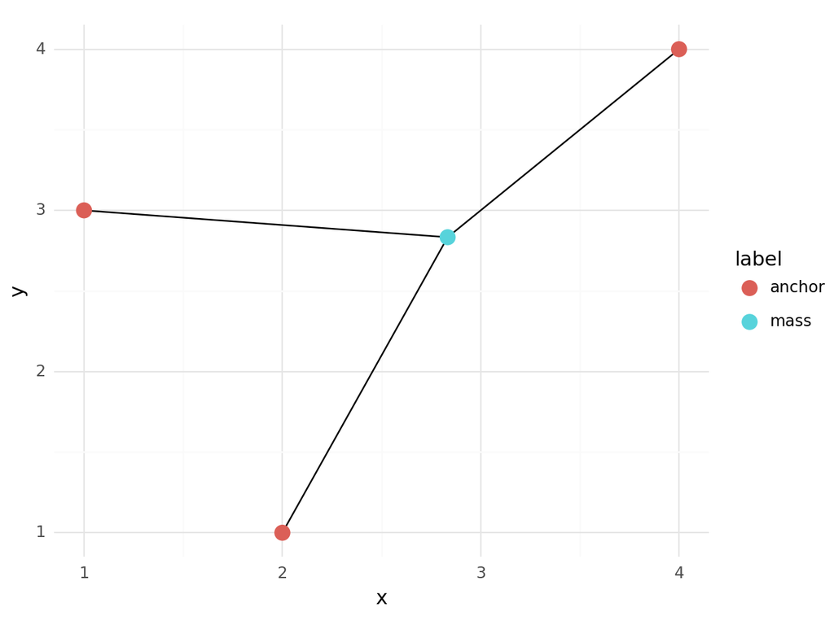

```
<Figure Size: (640 x 480)>
```

```python
###
# TASK: Set the gradient equal to zero, use this to solve for x_star
###

# NO NEED TO EDIT; use these constants in your function
# Spring constants
k1 = 1; k2 = 2; k3 = 3

# Anchor points
V = np.array([
    [1, 3],
    [2, 1],
    [4, 4],
])

def solve(k1, k2, k3):
    """
    Finds X* that is the minimum energy configuration for cables.
    Args:
        k1 (int): Spring constant of spring 1
        k2 (int): Spring constant of spring 2
        k3 (int): Spring constant of spring 3
    Returns:
        x_star (list): List containing x and y coordinates of the minimum energy configuration of the mass.
    """
    x_star = (k1*V[0] + k2*V[1] + k3*V[2])/(k1 + k2 + k3)
    return x_star

x_star = solve(k1, k2, k3)

# NO NEED TO EDIT; use the following code to check &
# visualize your work
print("q2.3 Diagnostics")
print("x_star =", x_star)
print("gradient =", gradient(x_star))
print()

assert(abs(x_star[0] - 2.833333) < 1e-6)
assert(abs(x_star[1] - 2.833333) < 1e-6)

# Visualize
df_optimized = gr.df_make(
        x=[x_star[0]] + list(V[:, 0]),
        y=[x_star[1]] + list(V[:, 1]),
        xend=x_star[0],
        yend=x_star[1],
        label=["mass"] + ["anchor"] * 3
    )

(
    df_optimized
    >> gr.ggplot(gr.aes("x", "y"))
    + gr.geom_segment(gr.aes(xend="xend", yend="yend"))
    + gr.geom_point(gr.aes(color="label"), size=4)
    + gr.theme_minimal()
)
```

One of the most important things we can do with optimization is combine our optimization with other analyses to do useful work. Sometimes optimization will be an inner component of a larger analysis. The next task will demonstrate one such analysis we can carry out.

### **q3.4** Use the solution to do useful work **UPDATED**

In the following I assume the spring constants $K$ can vary independently according to $K_i = 0.5 \pm 0.25$. I model the uncertainty in the spring constants probabilistically, and perform a Monte Carlo analysis to assess where the minimum-energy point tends to land based on this model. Your task is to interpret the results by answering the questions below.

```
eval_sample() is rounding n...
```

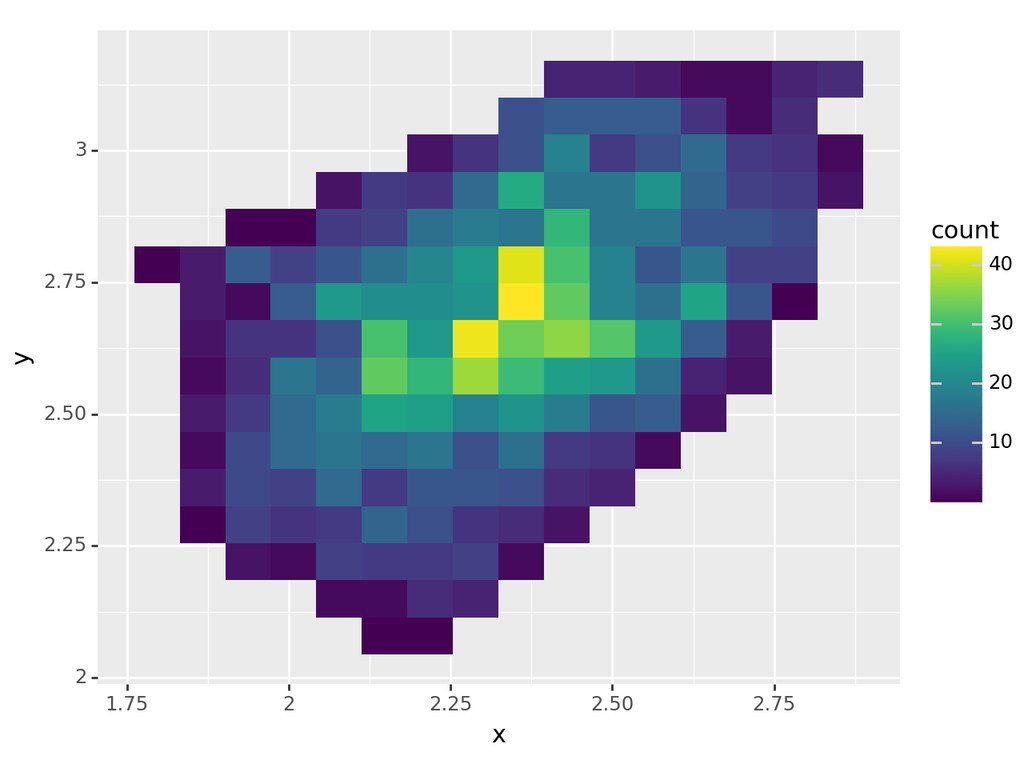

```
<Figure Size: (640 x 480)>
```

```python
###
# TASK: Run this code and interpret the results
###

# NO NEED TO EDIT THIS; run and interpret the results
# Construct Grama model using your function
md_point = (
    gr.Model("Minimum-energy point")
    >> gr.cp_function(
        fun=solve,
        var=["K1", "K2", "K3"],
        out=["x", "y"],
    )
    >> gr.cp_marginals(
        K1=dict(dist="uniform", loc=0.25, scale=0.5),
        K2=dict(dist="uniform", loc=0.25, scale=0.5),
        K3=dict(dist="uniform", loc=0.25, scale=0.5),
    )
    >> gr.cp_copula_independence()
)

# Generate data from model
df_results = (
    md_point
    >> gr.ev_sample(n=2e3, df_det="nom", seed=101)
)


# Visualize data
(
    df_results
    >> gr.ggplot(gr.aes("x", "y"))
    + gr.geom_bin2d(bins=15)
)
```

*Observe*: **UPDAED**

The highest-count region in `x, y` space is the most *likely* location of the minimum-energy point. Suppose you needed the minimum-energy point to lie within `0.1` units of a target position:

- What single `x, y` point---to within `0.1` units---is the most *likely* location for the minimum-energy point?
  - I would say point (2.37, 2.6), because that looks like the location of the center of the block with the highest count.
- Why do you claim that `x, y` point as the most likely location?
  - It's kind of between the other two light yellow blocks and it's along the line of the two main blocks? Like, the minimum location is moving along a line between the three anchor points, and my chosen points is kind of in the middle of those.
- How confident are you that a given set of `K_i` spring values---drawn at random according to the model above---will be within `0.1` units of the `x, y` point you selected?
  - Looking at the diagram, I am not confident that the randomly drawn K_i values using the model. While the pixels within x/y units around my chosen point have the highest counts of 40 each, many other pixels in the region have significant count numbers. With everything added up, I would not be confident that the mass would end up near my point.

### **q3.5** Return to the modeling context

Answer the following questions. Make sure to **justify** your answer for each question.

- For the actual Arecibo Observatory, if we imagine varying the *stiffness* of the cables, would you expect the *shape* of the possible `x, y` locations to be similar to, or completely different from, what you found in **q3.4**?
  - Yes, I would expect is to be similar.
  - I think it's reasonable to expect that if you're only looking at a 2D view (bird's eye) of the observatory, it's fair to think that at least the shape will be pretty similar. I think the shape might change in scale depending on the stiffness + variance of stiffness in the cables, but if all cables have the same base stiffness, possible variation, and anchor point location, I think the actual shape in which minimum energy change is achieved will be very similar.
- For the actual Arecibo Observatory, if we imagine varying the *lengths* of the cables, would you expect the *shape* of the possible `x, y` locations to be similar to, or completely different from, what you found in **q3.4**?
  - No? It depends on what you're looking for.
  - Personally I wouldn't use this model to find the lenghts of the cables because I suspect that the vertical component we explicitely ignore in this model may cause much larger sways in the shape.
- For the actual Arecibo Observatory, if we imagine varying the *stiffness* of the cables, can we use the same numbers you found in **q3.4** to make accurate predictions?
  - No, because these K values aren't realistic.
  - I think that these K values are pretty unrealistic, and therefore I wouldn't use these numbers to accurately predict the actual location of the mass. However, I do think that the shape is pretty realistic.

### q4.1 Model

*Task*: Find an image of your proposed system.

Chose an image like the Arecibo Observatory (Fig. 1): You should find an image that gives us a good sense of the system that you'll study in the natural world.

*Note*: To include an image in Jupyter notebook, put the image (e.g., `image.png`) in the same directory as your notebook, and use the following code (HTML) to include the image. You can use the `width` argument to set the pixel width of the image.

[figure not shown]

## S4: Project Tasks

Provide some early details on your project idea. These are not fixed in stone, but I want you to start thinking about this now. At this stage your project idea can be broad, and you can be considering multiple possibilities.

### q4.2 Math

*Task*: Provide an answer to each point below:

- *Physical System*: What physical system are you planning to study?
  - I'm thinking about simulating either a wind turbine (or a wind turbine farm, the problem here depends on the goal), or a nuclear reactor.
- *Question*: What question are you seeking to answer?
  - I'm not super sure yet? There are lots of directions I could go:
    - Wind (individual turbine): What is the minimum number of airfoils that maximize energy production? (How does this change under various wind conditions?)
    - Wind (farm): What is the ideal placement of wind turbines to maximize energy production?
    - Nuclear: What reactor design uses the least amount of uranium and water while optimizing energy production?
- *Optimization objective*: What objective(s) are you seeking to optimize? How well can you formulate those mathematically?
  - For wind, I think the objective for the individual is the material cost vs. the energy produced, for the farm it's the amount of wash from other wind turbines vs. the energy produced, and for the reactor it's maximum energy produced with minimizing environmental impact/material usage.
- *Optimization variables*: What variables will you optimize your objective with respect to? (the `wrt` line in your optimization.)
  - Wind (individual): Chord length, drag coefficient, lift coefficient, lift gradient, power coefficient, rotor diameter, number of blades, rotor radius, torque, relative wind velocity, angle of attack, pitch angle, inflow angle, tip-speed ratio, rotational speed
  - Wind (farm): ", wake circulation?
  - Nuclear: fuel enrichment level, number of rods, radius of fuel rods, length of fuel rods, spacing of rods, core diameter, core height, control rod placement, coolant flow rate, operating temperature, pressure.
- *Uncertainties*: What sources of uncertainty does your problem have?
  - Wind (individual): The performance depends on the blades being exactly the same, it would only apply to specific wind situations (direction, changes in direction, speed, air density and contents), this does not necessarily apply to more complex wind environments (wind farms, offshore turbines, forests/plains/cities), also would only apply to one "kind" of turbine (vertical vs. horizontal)
  - Wind (farm): wake behavior from other turbines, atmospheric conditions, manufacturing variability
  - Nuclear: Model simplifications fo design (2D vs. 3D), efficiency of fuel (and things like using all particles of fuel)
- *Stakeholders*: Your optimization results **must** be anchored by the concerns of a stakeholder group. Clearly state who your stakeholders are, and briefly descibe their stake in your project.
  - Wind (individual) + Wind (farm): Government organizations, renewable energy companies, manufacturing companies
  - Nuclear: Government organizations, environmental organizations (government and private), residents around nuclear sites, nuclear energy companies

### q4.3 People

- Why are **you** interested in this project? Why does it matter **to you**?
  - Both of these projects fall within the future of energy production, which feels very important for me to keep in touch with, even if I don't end up working in these industries. I am also taking this class as my MechE elective, which means that I have to stick within that space for my final project, and this feels very squarely in that area.
  - Wind energy feels like a classic aerodynamic problem that's very applicable to MechEs, and I have experience working with openfast, which is an open source software to simulate wind turbines under different load cases.
  - Nuclear feels less obviously mechanical, but I'm interested in learning more about the inner workings of nuclear.